# eBird Observations Dashboard

- eBird - online birdwatcher observation data crowdsourcing platform
- eBird Observation Dataset (EOD)
  - Decades of bird observation data from around the world
  - Very large dataset (millions of rows)
- Our focus is on South America from 2015-2020
1. How do individual birdwatcher survey habits affect the number and location of specie sightings?
2. Is there an association between geographic location and season, and what/how many species were sighted?
   - Did COVID have a significant impact on birding in 2020?
3. What is the forecast for the sightings of select species over the next 12 months?

**Activity Habits**

[interactive chart not shown]

- 39,222 birdwatchers, over 1.4 million checklists
  - Multiple birdwatchers can be associated with same checklist
- obsr501068 produced 6,293 checklists (0.436% of all checklists)
  - No clear overall major contributors
- Top 10 birdwatchers generally collected most of their samples in 2017 or 2019
  - 9/10 see a noticeable dip in 2020 - could this be due to COVID and quarantining?

**Seasonal Habits**

[interactive chart not shown]

- Spring and Summer are when most checklists are conducted, indicating higher birdwatching activity during these seasons
  - May introduce some seasonal bias

**Regional Habits**

| recordedBy | eventYear countryCode | 2015 | 2016 | 2017 | 2018 | 2019 | 2020 | Total Birdwatcher Checklists | % of Total Country Checklists |
| --- | --- | --- | --- | --- | --- | --- | --- | --- | --- |
| obsr626844 | CW | 9.0 | 217.0 | 1165.0 | 795.0 | 950.0 | 613.0 | 3749.0 | 56.410 |
| obsr161124 | PA | 1.0 | 0.0 | 0.0 | 0.0 | 0.0 | 0.0 | 1.0 | 50.000 |
| obsr221425 | PA | 1.0 | 0.0 | 0.0 | 0.0 | 0.0 | 0.0 | 1.0 | 50.000 |
| obsr614487 | GF | 11.0 | 49.0 | 369.0 | 529.0 | 465.0 | 575.0 | 1998.0 | 43.864 |
| obsr494376 | GY | 161.0 | 155.0 | 362.0 | 247.0 | 178.0 | 172.0 | 1275.0 | 22.082 |
| obsr660137 | AW | 50.0 | 22.0 | 192.0 | 319.0 | 246.0 | 330.0 | 1159.0 | 18.511 |
| obsr601024 | GF | 0.0 | 0.0 | 0.0 | 0.0 | 321.0 | 474.0 | 795.0 | 17.453 |
| obsr233415 | FK | 10.0 | 4.0 | 7.0 | 80.0 | 281.0 | 152.0 | 534.0 | 16.803 |
| obsr518406 | AW | 20.0 | 114.0 | 173.0 | 134.0 | 270.0 | 316.0 | 1027.0 | 16.403 |
| obsr321540 | FK | 18.0 | 5.0 | 3.0 | 130.0 | 81.0 | 261.0 | 498.0 | 15.670 |

- Individual birdwatchers can have a significant impact on the number of checklists for a country but not overall
  - obsr626844 contributed >%56 of Curaçao’s checklists

**Checklists & Sightings Correlation**

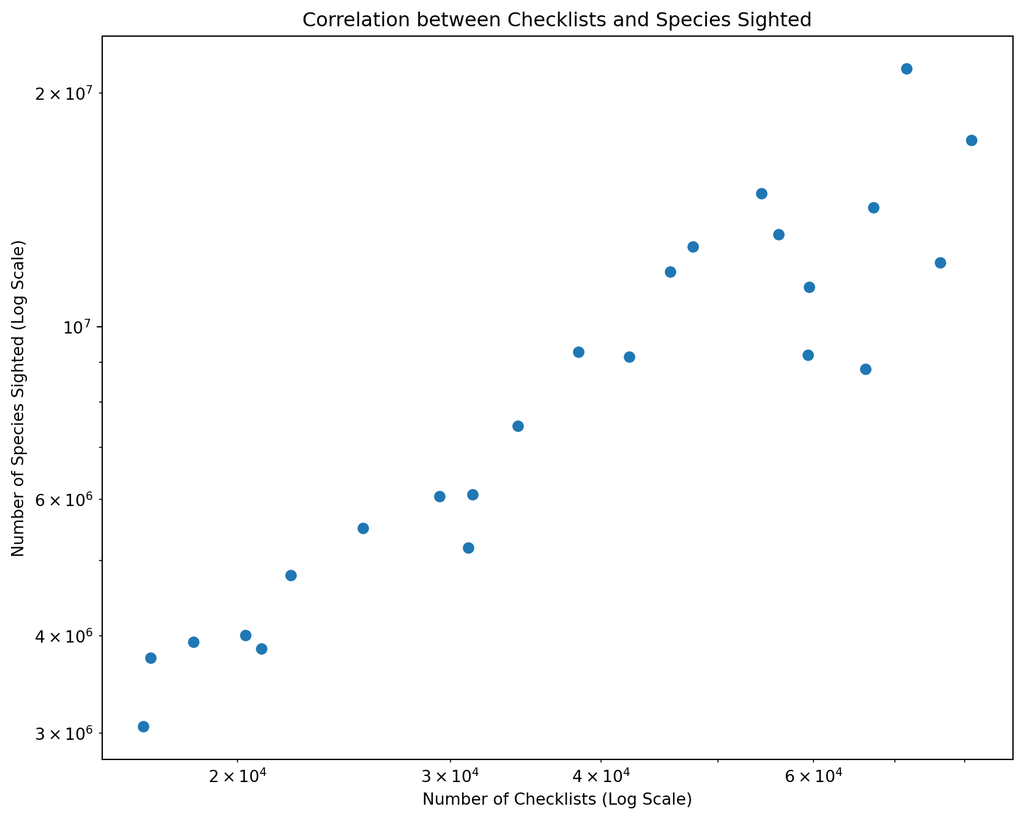

- Relatively strong positive correlation between number of checklists and number of sightings
- Key takeaway: where/when people are birding (producing checklists) correlates to more birds being seen
  - Possibility for sampling bias (under/over)

**Sightings by Location**

[interactive chart not shown]

- 5 countries (Argentina, Peru, Colombia, Chile, Brazil) contain vast majority of sightings
- Sampling bias: birds in these countries may be overcounted, birds in other countries may be undercounted

**Sightings by Season**

[interactive chart not shown]

- Most countries see peak sightings in Spring/Summer
  - Colombia is only exception, peaking in Winter
- Seems to be an association between country and season, and number of sightings

**Time Series**

[interactive chart not shown]

- Goal: forecast sightings for Pyrrhura Frontalis (maroon-bellied conure) over next 12 months
- Observe: sightings generally peak during April, June, and September
  - Possible seasonality

**Forecast**

[interactive chart not shown]